# Mapping with microbes, machine learning and XBoost predicts location

# Data Preperation

Load useful packages

```r
library(sp)
library(rworldmap)
library(caret)
library(maps)
library(MASS)
library(randomForest)
library(geosphere)
library(DiagrammeR)
library(doParallel)
library(caret)
library(plyr)
library(randomcoloR)
library(RColorBrewer)
library(maptools)
library(rgeos)
library(mapplots)
```

First we import the metasub datasets for metadata (city, latitude, longitude etc) and bacterial abundance data. Merge these sets by sample ID.

Control samples are be removed for obvious reasons.

```r
#Import data sets
complete_meta <- read.csv(file = "complete_metadatav2.csv", header = TRUE)
bac_data <- read.csv(file= "refseq.krakenhll_species (1).csv", header = TRUE)

#Change NA's to 0 in bacterial abundance data
bac_data[is.na(bac_data)] <- 0

#merge bacterial and meta data
metasub_data <- merge(complete_meta,bac_data,by.x="uuid",by.y="uuid")

#Remove control samples
control_samples <- c( which(metasub_data$city %in% c("control", "other_control","neg_control","other","pos_control")), which(metasub_data$control_type %in% c("ctrl cities","negative_control","positive_control")))
metasub_data <- droplevels(metasub_data[-c(control_samples), ])
```

We will also remove some samples for which the origin isn’t clear e.g. the name of the origin does match the co-ordinates. Samples from bouroughs within london will be re-labelled simply as London for consistency.

There are a group of samples from small towns accross uk, we will remove these as there are very few from each town and they will clutter up results A LOT while ading little improvement to a model on a global scale

```r
#remove sparse samples locations and dubiously labelled samples.
remove_samples <- which(metasub_data$city %in% c("tsuruoka", "antarctica","lands_end", "birmingham", "belfast", "bradford", "bristol","bury","cairngorm", "edinborough", "jaywick", "newcastle","swansea","eastbourne", "st_louis", "eden"))
metasub_data <- metasub_data[-c(remove_samples), ]

#re-label london boroughs
metasub_data$city[metasub_data$city %in% c("kensington","islington")] <- "london"
metasub_data <- droplevels(metasub_data)
```

```r
#Correction of identified misslabelling of data
metasub_data$latitude[metasub_data$city == "kyiv"] <- metasub_data$city_latitude[metasub_data$city == "kyiv"]
metasub_data$longitude[metasub_data$city == "kyiv"] <- metasub_data$city_longitude[metasub_data$city == "kyiv"]
metasub_data$continent[metasub_data$city == "porto"] <- "europe"
```

Not all of the samples have exact origin co-ordinates recorded, for the purposes of global predictions we can substitute the central co-ordinates of the city of origin for the missing exact co-ordiantes, found in the city meta-data. On the global scale this shouldn’t be too much of an issue.

```r
#impute unknown exact co-ords for city co-ords
metasub_data[is.na(metasub_data$latitude),]$latitude <- metasub_data[is.na(metasub_data$latitude),]$city_latitude
metasub_data[is.na(metasub_data$longitude),]$longitude <- metasub_data[is.na(metasub_data$longitude),]$city_longitude

#correction to some incorrect city co-ords for a few london samples
metasub_data[metasub_data$city == "london",]$city_latitude <- 51.50853
metasub_data[metasub_data$city == "london",]$city_longitude <- -0.12574
```

# Feature selection

This dataset contains rather a large amount of predictor variables, many of which will be random noise and detrimental to both model accuracy and computation time.

To select an optimum set of variables for each of the target variables of interest (city,latitude and longitude) we will use recursive feature elimination with random forests. The caret function “rfe” uses re-sampling and external validation to protect against selecting features that lead us to overfit the training data. More information is avalable at https://topepo.github.io/caret/recursive-feature-elimination.html

```r
set.seed(123)

#Activate parallel processing
registerDoParallel(parallel::detectCores() - 1)

#recursive feature elimination for the target variable "city"
rfe_ctrl <- rfeControl(functions = rfFuncs,
                   method = "cv",
                   number =  5,
                   verbose = FALSE,
                   allowParallel = TRUE
                   )
featureElimination <- rfe(x = metasub_data[, c(43:3799)],y = metasub_data$city,
                 sizes = c(100,200,300,400,500),
                 rfeControl = rfe_ctrl,
                 tuneLength = 0
                 )

optimumVarsCity <- featureElimination$optVariables[1:200]
```

Here we can see the effect of selecting smaller subsets of features on preict city of origin.

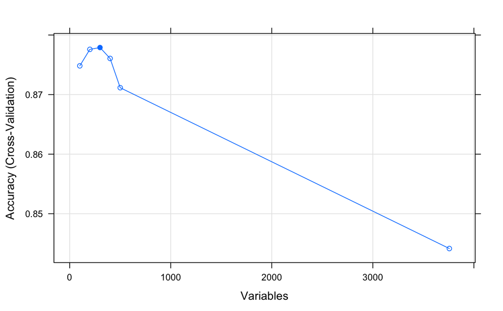

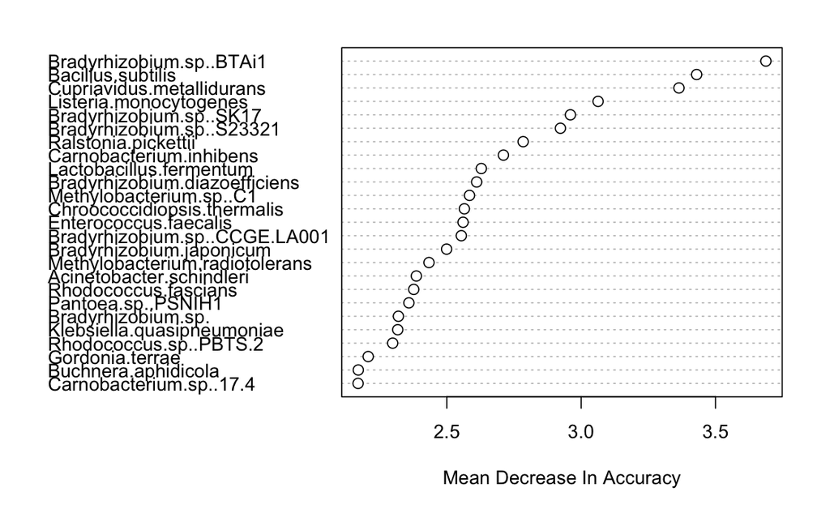

# Modeling

Our model makes use of regressor chains (more info: http://cig.fi.upm.es/articles/2015/Borchani-2015-WDMKD.pdf) in order to preoduce multi output predictions for class (city), latittude and longitude. This techniques involves chaining predictions for a series of outputs as input features for the next level model. In this case 3 chained XGboost models are used with hyperparameter tuning carried out by 5-fold cross validation of the trainng set using grid search methods.

Here this function here takes 4 arguments: a training set, a test set, a target class variable, a set of variables to use when training the model. The function outputs the class,latitude and longitude predictions from applying this model to the input test set.

```r
MappingModel <-  function(training,testing,classTarget,variables){

set.seed(1234)
folds <- createFolds(training[,classTarget], k = 5, returnTrain = T)



   trControlClass <-  trainControl(
   method = "cv",
   number = 5,
   verboseIter = FALSE,
   returnData = FALSE,
   search = "grid",
   savePredictions = "final",
   classProbs = T,
   allowParallel = T,
   index = folds )



   trControl <-  trainControl(
   method = "cv",
   number = 5,
   verboseIter = FALSE,
   returnData = FALSE,
   search = "grid",
   savePredictions = "final",
   allowParallel = T,
   index = folds)



     tune_grid <- expand.grid(
        nrounds = c(400,600),
        eta = c( 0.05, 0.1),
        max_depth = c(3,6,9),
        gamma = 0,
        colsample_bytree = c(0.6,0.8),
        min_child_weight = c(1),
        subsample = (0.7)
      )



      Xgb_class <- train(x = training[,variables],y = training[,classTarget],
         method = "xgbTree",
         trControl = trControlClass,
         tuneGrid = tune_grid)

      l2_train <- data.frame(training[,c(variables)],Xgb_class[["pred"]][order(Xgb_class$pred$rowIndex),levels(training[,classTarget]) ])


            Xgb_latitude <- train(x = l2_train ,y = training[,"latitude"],
               method = "xgbTree",
               trControl = trControl,
               tuneGrid = tune_grid)

            l3_train <- data.frame(l2_train, "latPred" = Xgb_latitude[["pred"]][order(Xgb_latitude$pred$rowIndex),"pred" ])

                   Xgb_longitude <- train(x = l3_train ,y = training[,"longitude"],
                     method = "xgbTree",
                     trControl = trControl,
                     tuneGrid = tune_grid)




                  classPred <- predict(Xgb_class, newdata = testing[,variables])
                  classProbs <- predict(Xgb_class, newdata = testing[,variables],type ="prob")

                        l2_test <-  data.frame(testing[,variables], classProbs)
                           latPred <- predict(Xgb_latitude, newdata = l2_test)

                           l3_test <- data.frame(l2_test, latPred)
                              longPred <- predict(Xgb_longitude, newdata = l3_test)






return(list(classPred, latPred, longPred))

}
```

```r
#generate 10 stratified folds for test predictions.
set.seed(18)
trainFolds <-  createFolds(metasub_data$city, k = 5, returnTrain = T)


GeoPreds <- list()
registerDoParallel(5)
#iteratively train the model on each of the 10 training folds and generate predictions using the coresponding test fold.
for (i in 1:5){

train <- metasub_data[trainFolds[[i]],]
test <- metasub_data[-trainFolds[[i]],]

testPreds <-MappingModel(training = train, testing = test, classTarget = "city",variables = optimumVarsCity)
GeoPreds[[i]] <- testPreds

}



add_preds <- list()
for (i in 1:5){

   add_preds[[i]] <- cbind(metasub_data[-trainFolds[[i]],] ,
                                 "cityPred"= GeoPreds[[i]][[1]],
                                 "latPred" = GeoPreds[[i]][[2]],
                                 "longPred" = GeoPreds[[i]][[3]] )



}

MetasubDataPreds <- rbind.fill(add_preds)
MetasubDataPreds[MetasubDataPreds$longPred > 180,"longPred"] <- 180.000

##Final stage is to adjust any co-ordinates that are in the sea and pull them to the nearset land mass

#get world coastlines
coastlines <- cbind("x"  = SpatialLines2map(coastsCoarse)$x ,"y" =SpatialLines2map(coastsCoarse)$y)
   coastlines <- coastlines[complete.cases(coastlines),]
      coastlines <- coastlines[coastlines[,1] < 180 ,]

#Function to find the nearest land point of any GPS co-ordinates
find_coast <- function(long,lat){
    distances_from_coastline <-  spDistsN1(coastlines , c(long,lat), longlat = TRUE)

                                    closest_point <-  which.min(distances_from_coastline)
                                    new_coords <- coastlines[closest_point,]

                                       return(new_coords)

                                     }

      GPS_where <- map.where(database = "world", MetasubDataPreds$longPred, MetasubDataPreds$latPred)
         toAdjust <- MetasubDataPreds[which(is.na(GPS_where)),]
         adjusted <- mapply(find_coast, long = toAdjust$longPred, lat = toAdjust$latPred )

            MetasubDataPreds[which(is.na(GPS_where)), "latPred"] <- adjusted[2,]
            MetasubDataPreds[which(is.na(GPS_where)), "longPred"] <- adjusted[1,]
```

```r
print(c(mean(MetasubDataPreds$cityPred ==MetasubDataPreds$city)
   ,RMSE(MetasubDataPreds$latPred, MetasubDataPreds$latitude),
       RMSE(MetasubDataPreds$longPred, MetasubDataPreds$longitude)))
```

```
[1]  0.9262899  8.2106433 23.4692890
```

Now we have our predicions we can begin to visulize them in order to get a feel for the effectiveness of the algorithm, as in this context RMSE is hard to understand paractially. So we will use predicted co-ordinates to a generate the distance of predictions from the true origin.

```r
Distance_from_origin <- c()
for (i in 1:nrow(MetasubDataPreds)){
  MetasubDataPreds[i,"Distance_from_origin"] <- distm(c(MetasubDataPreds[i,"longPred"],MetasubDataPreds[i,"latPred"]), c(MetasubDataPreds[i,"longitude"],MetasubDataPreds[i,"latitude"]), fun = distHaversine)/1000
}

print(c(mean(MetasubDataPreds$Distance_from_origin ),
median(MetasubDataPreds$Distance_from_origin ),
mean(MetasubDataPreds$Distance_from_origin < 500) ) )
```

```
[1] 1013.4403826  256.7242975    0.6402948
```

The mean distance of the origin prediction from the tru origin is 1013km and median 256.7 with 64% of samples within 500km

We can plot the predicted origin of each global sample. Coloured by continent of origin. City prediction accuracy is showm by the pie charts.

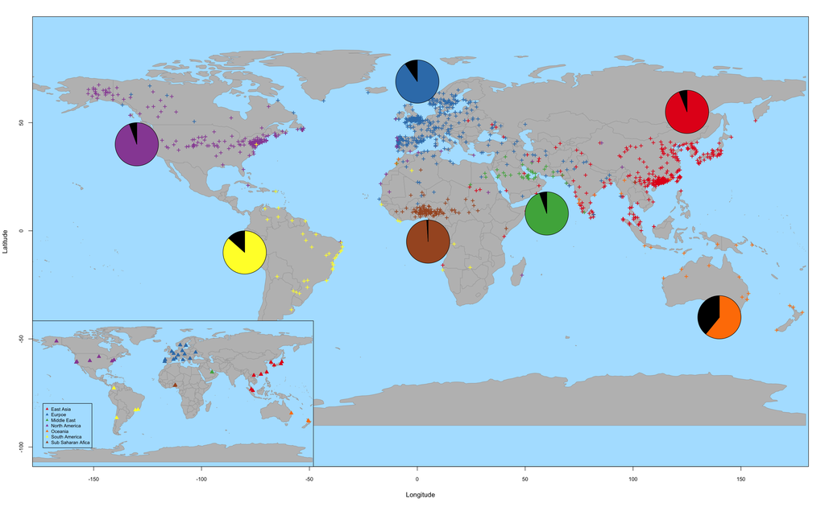